# Principal Component Analysis (PCA)

# Post-hoc Comparisons

### Which Sites Differ?

```
##  contrast  estimate    SE df t.ratio p.value
##  DG - HD     -3.651 0.673 83  -5.427  <.0001
##  DG - LEH    -0.366 0.542 83  -0.675  0.9064
##  DG - TJH    -1.447 0.542 83  -2.671  0.0442
##  HD - LEH     3.285 0.673 83   4.883  <.0001
##  HD - TJH     2.204 0.673 83   3.276  0.0082
##  LEH - TJH   -1.082 0.542 83  -1.996  0.1977
##
## P value adjustment: tukey method for comparing a family of 4 estimates
##  site emmean    SE df lower.CL upper.CL .group
##  DG   -1.024 0.383 83   -1.786   -0.262  a
##  LEH  -0.659 0.383 83   -1.421    0.103  ab
##  TJH   0.423 0.383 83   -0.339    1.185   b
##  HD    2.626 0.553 83    1.526    3.726    c
##
## Confidence level used: 0.95
## P value adjustment: tukey method for comparing a family of 4 estimates
## significance level used: alpha = 0.05
## NOTE: If two or more means share the same grouping symbol,
##       then we cannot show them to be different.
##       But we also did not show them to be the same.
```

# Distance Between Sites

### Calculating Euclidean Distance Between Groups

- Calculate the distance between site centroids (mean PC scores):
  - $d_{k,j} = \sqrt{\sum_{i=1}^{p}(\bar{Z}_{i,k} - \bar{Z}_{i,j})^2}$
  - Where $\bar{Z}_{i,k}$ is the mean of PC *i* for site *k*.
- **Using all PCs** preserves the true Euclidean distance from the original data.
- **Using just PC1-PC3** (77% of variance) gives approximate distances.

**HD is most different** from other sites (smallest plants).

```r
# Calculate site centroids (means)
site_means <- pc_scores %>%
  group_by(site) %>%
  summarize(across(PC1:PC3, mean))

site_means
## # A tibble: 4 × 4
##   site     PC1    PC2    PC3
##   <chr>  <dbl>  <dbl>  <dbl>
## 1 DG    -1.02   0.604  0.542
## 2 HD     2.63  -0.863 -1.26
## 3 LEH   -0.659  0.155 -0.555
## 4 TJH    0.423 -0.345  0.618

# Calculate distance matrix
site_dist <- site_means %>%
  dplyr::select(PC1, PC2, PC3) %>%
  dist() %>%
  round(3)
site_dist
##       1     2     3
## 2 4.328
## 3 1.241 3.511
## 4 1.732 2.942 1.672
```

# Visualization of the distances

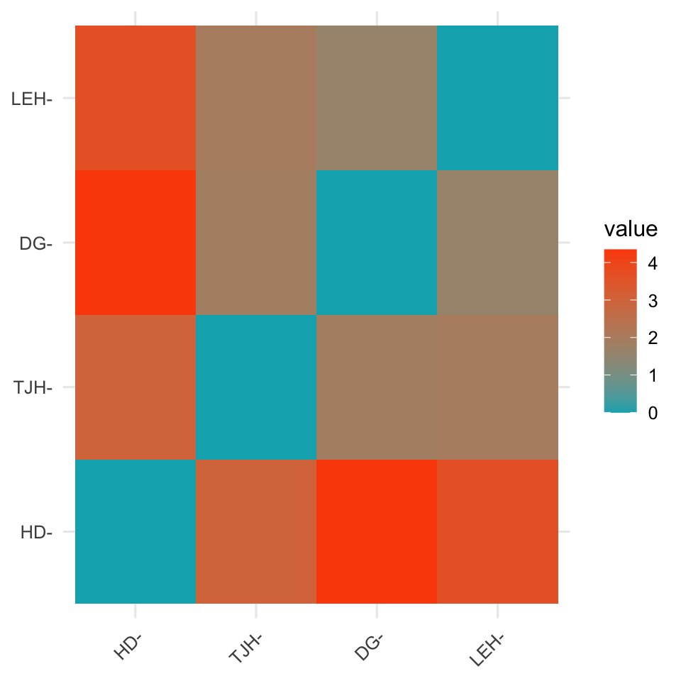

```r
# 1. Prepare PC Scores with Site
pc_scores_for_dist <- as.data.frame(pca_result$x) %>%
  mutate(site = darlingtonia$site)

# 2. Calculate the mean PC scores for each site (the site "centroids")
site_centroids <- pc_scores_for_dist %>%
  group_by(site) %>%
  summarise(across(starts_with("PC"), mean)) %>%
  ungroup()

# 3. Set site names as row names BEFORE calculating distances
site_centroids_matrix <- site_centroids %>%
  column_to_rownames("site")  # This keeps site names as row names

# 4. Calculate the Euclidean distance matrix between site centroids
dist_matrix <- dist(site_centroids_matrix, method = "euclidean")

# Display the distance matrix
dist_matrix
##           DG       HD      LEH
## HD  4.346434
## LEH 1.621198 3.659711
## TJH 1.843120 3.021386 1.960547

# Visualize the distance matrix
fviz_dist(dist_matrix,
          gradient = list(low = "#00AFBB", high = "#FC4E07"))
```

# Summary: PCA Results for Darlingtonia

# When to Use PCA

- PCA is Appropriate When:
  - Variables are **continuous** (not categorical)
  - Variables are **correlated** (redundancy exists) + **Linear relationships**
  - Goal is **dimension reduction** or **data exploration**
  - **Sample size** adequate (at least 3× number of variables)
- PCA Assumptions:
  - **Linearity**: relationships between variables are linear
  - **Adequate correlation**: variables must be correlated
  - **No severe outliers**: can distort results
  - **Sample size**: need enough observations
- Always Check:
  - Correlation matrix (are variables correlated?)
  - Scree plot (how many components needed?)
  - Loadings (biological interpretation makes sense?)
  - Outliers (check scores plots)

# When to **Consider Alternatives:**

- **Different data types**:
  - Categorical variables → MCA (Multiple
  - Correspondence Analysis) - Species composition data → CA (Correspondence Analysis)
  - Distance/dissimilarity matrices → PCoA (Principal Coordinates Analysis)
- **Different goals**: - Classification → Discriminant Analysis
  - Non-linear patterns → NMDS (Non-metric Multidimensional Scaling)
  - Hypothesis testing → MANOVA
- **Problems with PCA**:
  - Strong outliers present
  - Non-linear relationships
  - Variables are uncorrelated
  - Many zeros in data
- **PCA works best** for morphological, physiological, and environmental variables!

# Additional PCA Diagnostics

### Checking Assumptions and Quality

1. Sampling Adequacy
- **Kaiser-Meyer-Olkin (KMO) Test**:
- Measures sampling adequacy
- Values > 0.6 = acceptable
- Values > 0.8 = good

```r
# KMO test requires psych package
KMO(cor(darl_numeric))
## Kaiser-Meyer-Olkin factor adequacy
## Call: KMO(r = cor(darl_numeric))
## Overall MSA =  0.76
## MSA for each item =
##       height   mouth_diam    tube_diam    keel_diam wing1_length wing2_length
##         0.64         0.84         0.47         0.61         0.85         0.80
##    wingsprea   hoodmass_g   tubemass_g   wingmass_g
##         0.76         0.78         0.72         0.86
```

### 2. Outlier Detection

Check for influential observations:

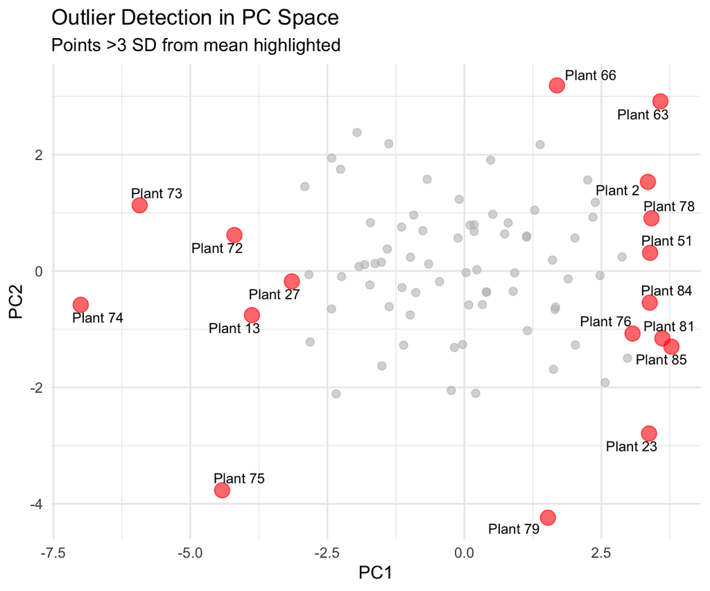

# PCA vs. Other Ordination Methods

## Comparison Table

| Method | Data Type | Distance/Similarity | Linear? | Eigenanalysis? |
| --- | --- | --- | --- | --- |
| **PCA** | Continuous, correlated | Euclidean (correlation) | Yes | Yes |
| **CA** | Count data, species | Chi-square | No | Yes |
| **PCoA** | Any (via distance matrix) | Any distance metric | N/A | Yes |
| **NMDS** | Any (via distance matrix) | Any distance metric | No | No |
| **DCA** | Species abundance | Weighted averaging | No | Yes |

# Advanced Topics in PCA

## Topics We Haven’t Covered

- **Factor Analysis**: - Similar to PCA but with different goals - Assumes latent “factors” cause observed variables - Uses rotation to improve interpretation - More common in social sciences
- **Robust PCA**: - Less sensitive to outliers - Uses robust covariance estimators - Useful with messy ecological data
- **Sparse PCA**: - Forces many loadings to exactly zero - Easier to interpret - Better for very high-dimensional data
- **Functional PCA**: - For time series or spatial data - Treats curves as observations - Common in physiology
- **Probabilistic PCA**: - Includes uncertainty estimation - Can handle missing data - Maximum likelihood framework
- **Kernel PCA**: - Handles non-linear relationships - Uses kernel trick from machine learning - More flexible but harder to interpret
- These are beyond our scope but worth knowing exist!

# Practical Tips for PCA

## Best Practices

### Before PCA:

1. **Explore your data**
   - Check distributions
   - Identify outliers
   - Understand variable scales
2. **Check correlations**
   - Make correlation plot
   - Ensure variables are correlated
   - Consider removing redundant variables
3. **Standardize appropriately**
   - Use `scale = TRUE` for different units
   - Consider centering only for same units
4. **Check sample size**
   - Need at least 3× variables
   - More is better (50+ ideal)

### During PCA:

1. **Examine scree plot**
   - Look for elbow
   - Consider cumulative variance
   - Usually keep 2-5 components
2. **Interpret loadings**
   - Look for patterns
   - Consider biological meaning
   - Ignore very small loadings
3. **Check scores plots**
   - Look for outliers
   - Identify patterns/groups
   - Consider site/treatment effects

### After PCA:

1. **Report clearly**
   - State why you used PCA
   - Report variance explained
   - Describe component interpretation
2. **Use results appropriately**
   - PC scores can go into other analyses
   - Don’t over-interpret small components
   - Remember: exploratory tool!

# Reporting PCA Results

## What to Include in Papers/Theses

### Essential Figures:

1. **Scree plot** - shows variance explained
2. **Loadings plot** - shows variable contributions
3. **Scores plot** or **biplot** - shows samples in PC space

### Essential Tables:

1. **Variance explained** by each PC
2. **Loadings** for retained PCs (usually PC1-PC3)
3. **ANOVA results** if testing groups

### Don’t Report:

- All 10 PCs if only 3 are meaningful
- Tiny loadings (< 0.3)
- Every individual PC score
- Raw eigenvalues (report % variance instead)

# Common PCA Mistakes to Avoid

## Mistakes Students Make:

❌ **Not standardizing** data with different units  
→ ✓ Always use `scale = TRUE` for different units

❌ **Forgetting to check correlations**  
→ ✓ Make correlation plot first

❌ **Using too many components**  
→ ✓ Use scree plot, keep components above elbow

❌ **Over-interpreting small loadings**  
→ ✓ Focus on loadings > |0.3|

❌ **Ignoring signs on loadings**  
→ ✓ Sign can flip; look at patterns

❌ **Treating PC scores as original data**  
→ ✓ Remember PCs are derived variables

❌ **Using PCA on categorical data**  
→ ✓ Use appropriate method (CA, MCA)

❌ **Not checking for outliers**  
→ ✓ Plot scores, check for extreme values

❌ **Assuming PCs have biological meaning**  
→ ✓ Interpret carefully, components are mathematical

❌ **Using PCA with too few samples**  
→ ✓ Need n > 3p (preferably n > 50)

❌ **Not reporting variance explained**  
→ ✓ Always report % variance for each PC

❌ **Forgetting that PCA is exploratory**  
→ ✓ Use for patterns, not hypothesis testing

# Practice Exercise

### Exercise 1: Subset Analysis

Try running PCA on just the **morphological variables** (exclude biomass):

```r
# Select only morphological variables
darl_morph <- darlingtonia %>%
  select(height, mouth_diam, tube_diam,
         keel_diam, wing1_length,
         wing2_length, wingsprea)

# Run PCA
pca_morph <- prcomp(darl_morph,
                    scale. = TRUE)

# Examine results
summary(pca_morph)

# How do results differ from full PCA?
```

### Exercise 2: Site-Specific PCA

Run PCA on just one site (e.g., DG):

```r
# Filter to one site
darl_dg <- darlingtonia %>%
  filter(site == "DG") %>%
  select(-site)

# Run PCA
pca_dg <- prcomp(darl_dg,
                 scale. = TRUE)

# Compare to overall PCA
summary(pca_dg)

# Do the same patterns emerge?
```

### Exercise 3: Interpretation

1. What does PC1 represent in each analysis?
2. How much variance is explained?
3. Do you see the same patterns?

# Some other ways

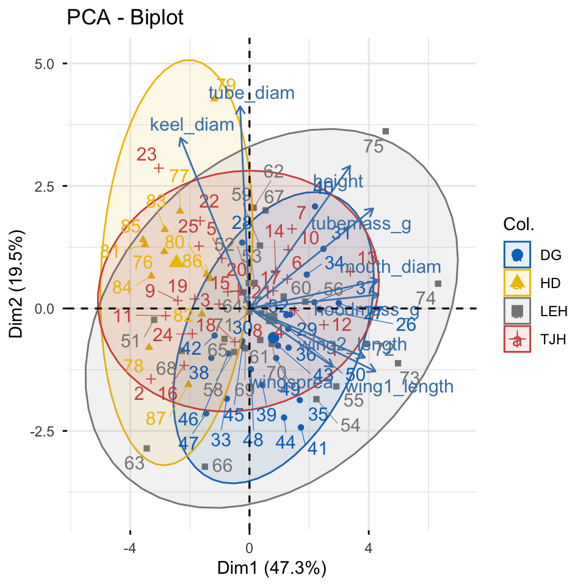

```r
# Create dataset with row names
darl_pca_data <- darlingtonia %>%
  select(height, mouth_diam, tube_diam, keel_diam,
         wing1_length, wing2_length, wingsprea,
         hoodmass_g, tubemass_g)

# PCA
pca_facto <- PCA(darl_pca_data,
                 graph = FALSE,
                 scale.unit = TRUE)

# Create grouping factor with same length
site_groups <- factor(darlingtonia$site)

# Plot with grouping
fviz_pca_biplot(pca_facto,
                col.ind = site_groups,  # Use col.ind instead
                palette = "jco",
                addEllipses = TRUE,
                ellipse.level = 0.95,
                repel = TRUE)
```

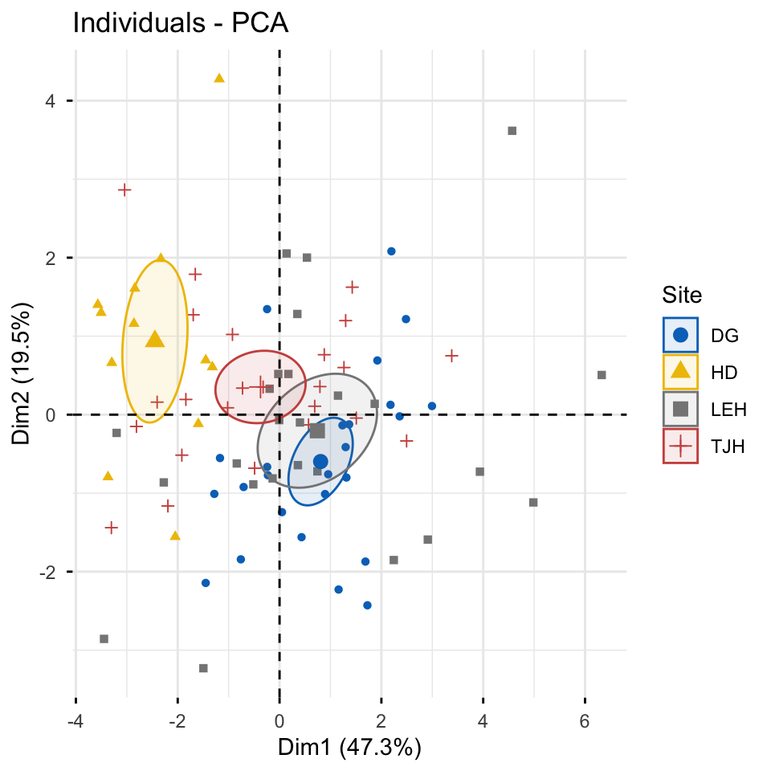

```r
# Individual plot with better options
fviz_pca_ind(pca_facto,
             geom.ind = "point",
             col.ind = darlingtonia$site,
             palette = "jco",
             addEllipses = TRUE,
             ellipse.type = "confidence",
             legend.title = "Site",
             repel = TRUE)
```

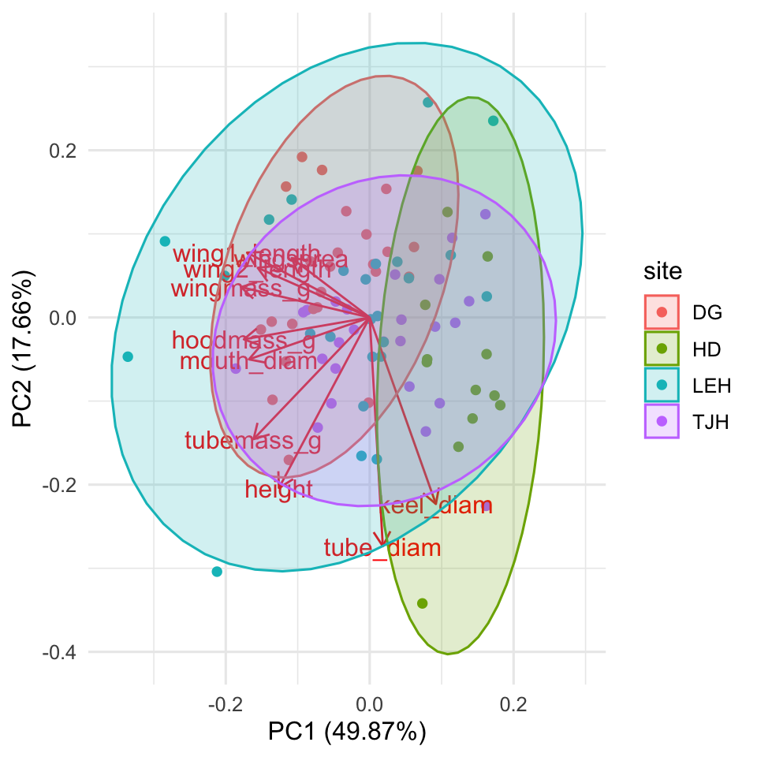

```r
# Quick PCA plot with ggplot2
autoplot(pca_result,
         data = darlingtonia,
         colour = 'site',
         loadings = TRUE,
         loadings.label = TRUE,
         frame = TRUE,  # Adds ellipses
         frame.type = 'norm')  # or 't' for confidence
```

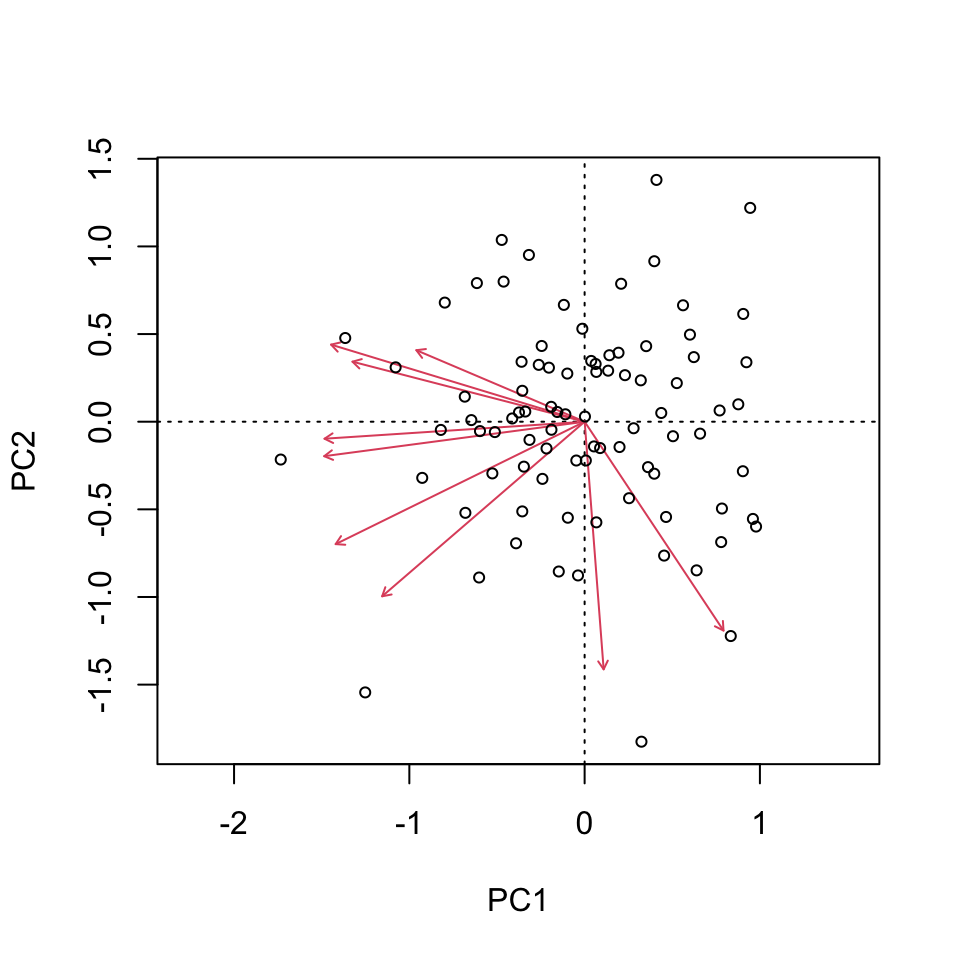

```r
# Prepare data matrix (samples × variables)
darl_matrix <- darlingtonia %>%
  select(height, mouth_diam, tube_diam, keel_diam,
         wing1_length, wing2_length, wingsprea,
         hoodmass_g, tubemass_g) %>%
  scale()

# PCA with vegan (uses SVD, similar to prcomp)
pca_vegan <- rda(darl_matrix)

# Quick plot
biplot(pca_vegan, scaling = 2)
```

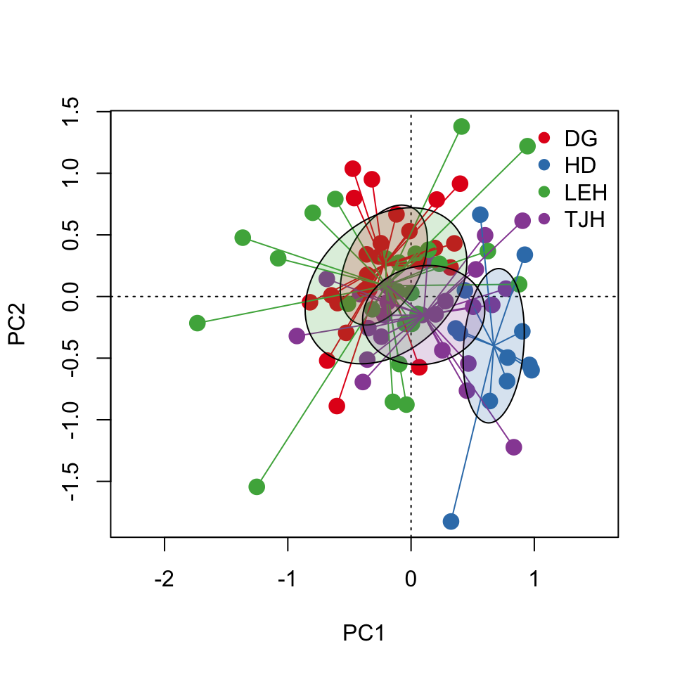

```r
# Calculate distances between sites
site_matrix <- darlingtonia %>%
  select(height, mouth_diam, wingmass_g) %>%
  mutate(site = darlingtonia$site) %>%
  group_by(site) %>%
  summarise(across(everything(), mean)) %>%
  column_to_rownames("site")

# Euclidean distance (many distance metrics available!)
dist_euclidean <- vegdist(site_matrix, method = "euclidean")
dist_bray <- vegdist(site_matrix, method = "bray")  # Bray-Curtis
dist_manhattan <- vegdist(site_matrix, method = "manhattan")

# Create a nice color palette
site_factor <- factor(darlingtonia$site)
n_sites <- length(levels(site_factor))
colors <- brewer.pal(min(n_sites, 8), "Set1")  # Use Set1 palette
site_colors <- colors[as.numeric(site_factor)]

# Ordination plot with sites
ordiplot(pca_vegan, type = "none")
points(pca_vegan, display = "sites", col = site_colors, pch = 19, cex = 1.5)
ordispider(pca_vegan, groups = darlingtonia$site, col = colors)
ordiellipse(pca_vegan, groups = darlingtonia$site, draw = "polygon",
            col = colors, alpha = 0.2)

# Add legend
legend("topright", legend = levels(site_factor),
       col = colors, pch = 19, bty = "n")
```

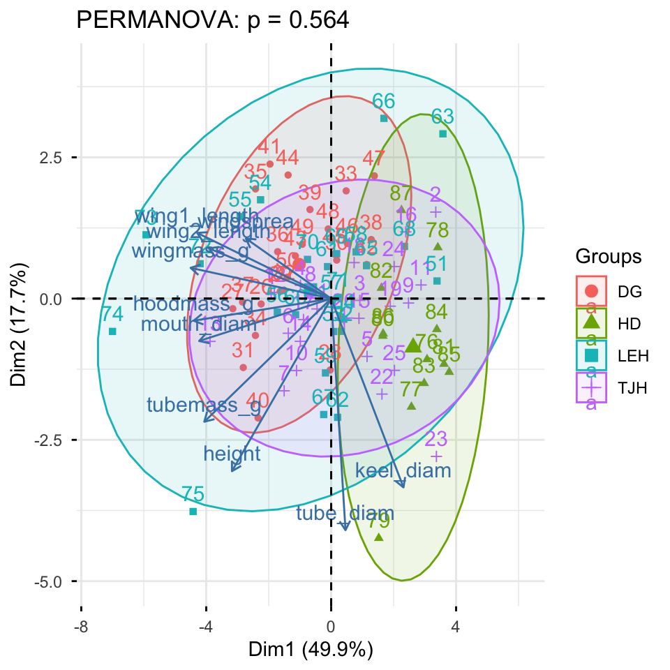

```r
# Analysis
pca_vegan <- rda(darl_matrix)
permanova <- adonis2(darl_matrix ~ site, data = darlingtonia)

# Visualization
fviz_pca_biplot(pca_result,
                habillage = darlingtonia$site,
                addEllipses = TRUE) +
  labs(title = paste0("PERMANOVA: p = ",
                      round(permanova$`Pr(>F)`[1], 3)))
```

```r
# Scale the data properly
darl_scaled <- darlingtonia %>%
  select(height, mouth_diam, tube_diam, keel_diam,
         wing1_length, wing2_length, wingsprea,
         hoodmass_g, tubemass_g) %>%
  scale() %>%
  as.data.frame()  # Convert back to data frame

# PERMANOVA
permanova_scaled <- adonis2(darl_scaled ~ site,
                           data = darlingtonia,
                           method = "euclidean",
                           permutations = 999)
permanova_scaled
## Permutation test for adonis under reduced model
## Permutation: free
## Number of permutations: 999
##
## adonis2(formula = darl_scaled ~ site, data = darlingtonia, permutations = 999, method = "euclidean")
##          Df SumOfSqs      R2      F Pr(>F)
## Model     3   189.72 0.24512 8.9836  0.001 ***
## Residual 83   584.28 0.75488
## Total    86   774.00 1.00000
## ---
## Signif. codes:  0 '***' 0.001 '**' 0.01 '*' 0.05 '.' 0.1 ' ' 1
```

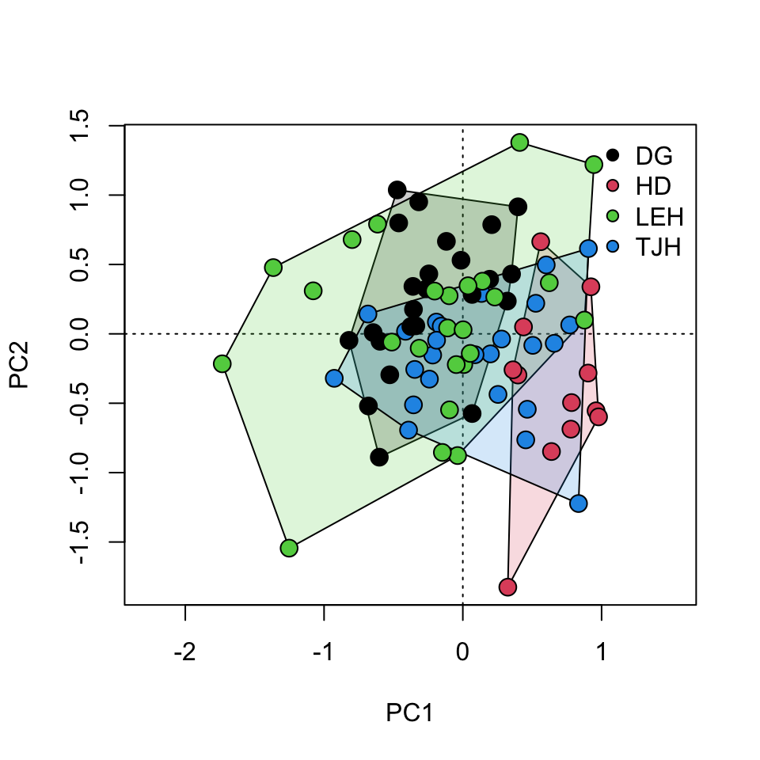

```r
# Ordination plot with convex hulls (simpler)
ordiplot(pca_vegan, type = "none")
ordihull(pca_vegan, groups = darlingtonia$site,
         draw = "polygon", col = 1:n_sites, alpha = 50)
points(pca_vegan, display = "sites", pch = 21,
       bg = as.numeric(factor(darlingtonia$site)), cex = 1.5)
legend("topright", legend = levels(factor(darlingtonia$site)),
       pt.bg = 1:n_sites, pch = 21, bty = "n")
```

```r
# Pairwise comparisons between sites
pairwise_result <- pairwise.adonis2(darl_scaled ~ site,
                                    data = darlingtonia,
                                    method = "euclidean",  # Add this!
                                    p.adjust.m = "bonferroni")
pairwise_result
## $parent_call
## [1] "darl_scaled ~ site , strata = Null , permutations 999"
##
## $TJH_vs_DG
##          Df SumOfSqs      R2      F Pr(>F)
## Model     1   32.602 0.10636 5.7128  0.002 **
## Residual 48  273.930 0.89364
## Total    49  306.532 1.00000
## ---
## Signif. codes:  0 '***' 0.001 '**' 0.01 '*' 0.05 '.' 0.1 ' ' 1
##
## $TJH_vs_LEH
##          Df SumOfSqs      R2      F Pr(>F)
## Model     1    47.72 0.10517 5.6414  0.004 **
## Residual 48   406.06 0.89483
## Total    49   453.78 1.00000
## ---
## Signif. codes:  0 '***' 0.001 '**' 0.01 '*' 0.05 '.' 0.1 ' ' 1
##
## $TJH_vs_HD
##          Df SumOfSqs      R2      F Pr(>F)
## Model     1   69.308 0.25135 11.751  0.001 ***
## Residual 35  206.432 0.74865
## Total    36  275.740 1.00000
## ---
## Signif. codes:  0 '***' 0.001 '**' 0.01 '*' 0.05 '.' 0.1 ' ' 1
##
## $DG_vs_LEH
##          Df SumOfSqs      R2      F Pr(>F)
## Model     1    26.24 0.06493 3.3333  0.022 *
## Residual 48   377.85 0.93507
## Total    49   404.09 1.00000
## ---
## Signif. codes:  0 '***' 0.001 '**' 0.01 '*' 0.05 '.' 0.1 ' ' 1
##
## $DG_vs_HD
##          Df SumOfSqs      R2      F Pr(>F)
## Model     1   131.09 0.42382 25.745  0.001 ***
## Residual 35   178.22 0.57618
## Total    36   309.31 1.00000
## ---
## Signif. codes:  0 '***' 0.001 '**' 0.01 '*' 0.05 '.' 0.1 ' ' 1
##
## $LEH_vs_HD
##          Df SumOfSqs     R2      F Pr(>F)
## Model     1   101.69 0.2468 11.468  0.001 ***
## Residual 35   310.35 0.7532
## Total    36   412.04 1.0000
## ---
## Signif. codes:  0 '***' 0.001 '**' 0.01 '*' 0.05 '.' 0.1 ' ' 1
##
## attr(,"class")
## [1] "pwadstrata" "list"
```

```r
# install.packages("RVAideMemoire")
library(RVAideMemoire)

# Pairwise PERMANOVA
pairwise.perm.manova(vegdist(darl_scaled, method = "euclidean"),
                     darlingtonia$site,
                     test = "Wilks",
                     nperm = 999,
                     p.method = "bonferroni")
##
##  Pairwise comparisons using permutation MANOVAs on a distance matrix
##
## data:  vegdist(darl_scaled, method = "euclidean") by darlingtonia$site
## 999 permutations
##
##     DG    HD    LEH
## HD  0.006 -     -
## LEH 0.114 0.006 -
## TJH 0.012 0.006 0.018
##
## P value adjustment method: bonferroni
```

Why the differences matter: Location (Centroid) Tests:

Back to top